# Network and Graph Analysis

### Visualization

Generate a plot of the simplified network, with the following visualization parameters. For vertices, a size of 10; any color of your preference for vertex, frame and label; and label size of 0.8. For edges, an arrow size of 0.3; any color of your preference; and a curve of 0.2. Use the LGL algorithm layout.

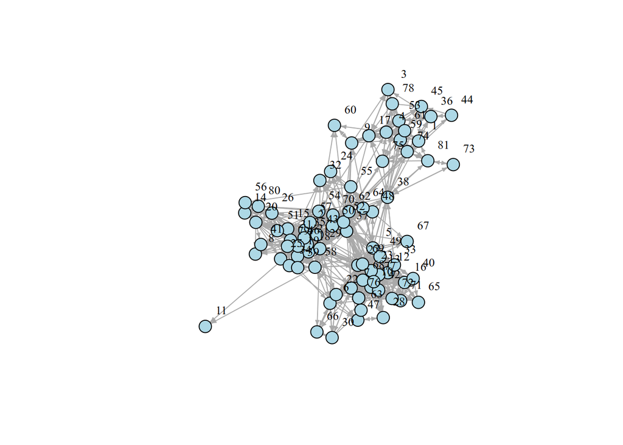

```r
plot(UKfacultys,
    edge.arrow.size = 0.3,
    vertex.color = "lightblue",
    vertex.size = 10,
    vertex.frame.color = "black",
    vertex.label.color = "black",
    vertex.label.cex = 0.8,
    vertex.label.dist = 2.5,
    curved = 0.2
)
```

### Refine the visualiztion replace the vertex labels with the node names stored in “Group”, inside the igraph object. Set a different node color depending on the Group each node belongs to. Remember that you might have to remove the vertex.color parameter, so it does not override your new colors. Finally, add a suitable title and a legend showing the colors that correspond to each group, and plot the graph.

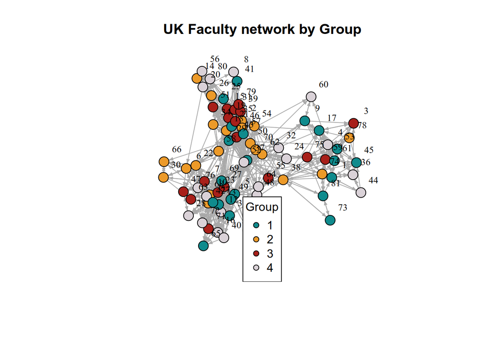

```r
plot(UKfacultys,
    edge.arrow.size = 0.3,
    vertex.size = 10,
    vertex.color = c("#0F8B8D", "#EC9A29", "#A8201A", '#DAD2D8'),
    vertex.frame.color = "black",
    vertex.label.color = "black",
    vertex.label.cex = 0.8,
    vertex.label.dist = 2.5,
    curved = 0.2,
    label = V(UKfacultys)$Group,
    main = 'UK Faculty network by Group'
)
legend(
    legend = c('1', '2', '3', '4'),
    "bottom",
    pch    = 21,
    cex    = 1,
    pt.bg  = c("#0F8B8D", "#EC9A29", "#A8201A", '#DAD2D8'),
    title    = "Group",
)
```

### Network attributes Calculate the density, transitivity (global and local) and diameter (with weights, considering the network first directed and then undirected) of the graph.

```r
global_metric <- cbind(
    size    = vcount(UKfacultys),
    nedges  = ecount(UKfacultys),
    density = edge_density(UKfacultys),
    recip   = reciprocity(UKfacultys),
    centr   = centr_betw(UKfacultys)$centralization,
    pathLen = mean_distance(UKfacultys),
    transitivity_g = transitivity(
  UKfacultys,
  type = "global",
  vids = NULL,
  weights = NULL,
  isolates = "zero"
),
transitivity_l = transitivity(
  UKfacultys,
  type = "local",
  vids = NULL,
  weights = NULL,
  isolates = "zero"
),
diameter_ud = diameter(UKfacultys, directed = F, unconnected = TRUE, weights = NULL),
diameter_d = diameter(UKfacultys, directed = TRUE, unconnected = TRUE, weights = NULL)
)
```

According to the value of the global transitivity, which is

```r
global_metric[,"transitivity_g"][1]
```

```
#> [1] 0.4896236
```

Almost half of the triplets are closed.

Look at the different diameters obtained by considering the network directed or undirected.

```r
global_metric[, "diameter_ud"][1] > global_metric[, "diameter_d"][1]
```

```
#> [1] FALSE
```

the directional diameters are larger.

This is reasonable as the directional network is a sub-network of the undirectional one.